# response_pollen_sum_filtering

## Response Draft: Pollen-Sum Filtering

We appreciate the reviewer’s concern regarding low pollen-count samples and potential impacts on PAP estimates.

We agree that this point requires explicit quantification and clarification in both the manuscript and response letter. We have now added targeted diagnostics that directly evaluate retained sample-count distributions and the consequences of stricter pollen-count thresholds for record and sample retention.

First, we clarify that the low-count values are used as filtering thresholds in preprocessing, not as a blanket forcing of all samples to one fixed count in the diagnostics presented here. To evaluate whether low-count samples dominate the retained dataset, we quantified the empirical sample-count distribution in the baseline filtered data ($N = 75,383$ samples).

94.8% of samples have >=150 grains; 83.1% of samples have >=300 grains; 50.3% of samples have >=500 grains; 19.9% of samples have >=1,000 grains.

Thus, the retained dataset is not dominated by very low-count samples.

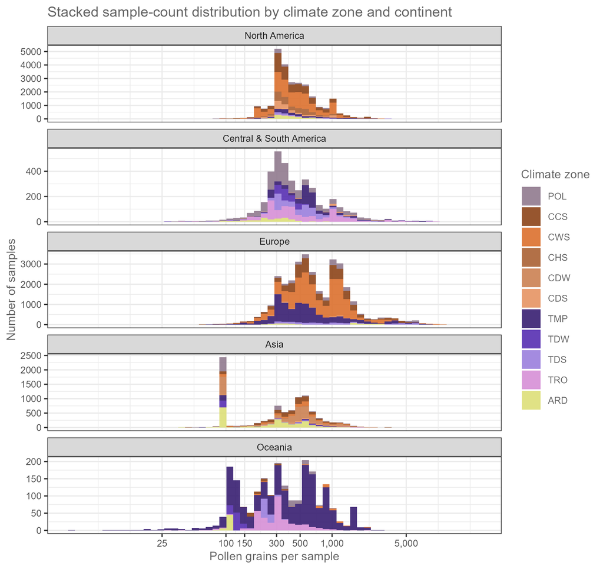

Figure 1: Distribution of retained sample pollen sums by continent and climate zone.

Second, we evaluated sensitivity to stricter thresholds by recomputing retention at higher count criteria relative to the baseline threshold (150).

Record retention is 87.0% at 300, 48.5% at 500, 19.4% at 1,000. Sample retention is 90.0% at 300, 54.7% at 500, 24.1% at 1,000.

Third, we now present retention summaries globally, by continent, and by continent-climatezone combinations to show where losses occur under stricter filtering. This makes the representational trade-off transparent rather than implicit.

In response to the reviewer, we have therefore strengthened both the methods text and supplementary evidence by adding: (i) explicit reporting of retained pollen-sum distributions, (ii) explicit retention sensitivity analyses at higher thresholds, and (iii) clearer framing that PAP-based analyses are in the pollen domain and remain subject to known compositional and production biases.

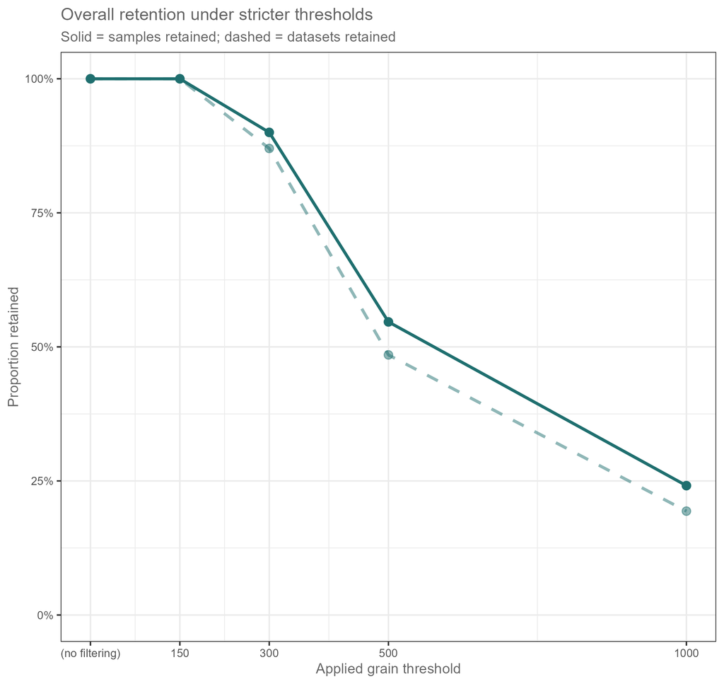

Figure 2: Overall retention sensitivity under stricter pollen-sum thresholds.

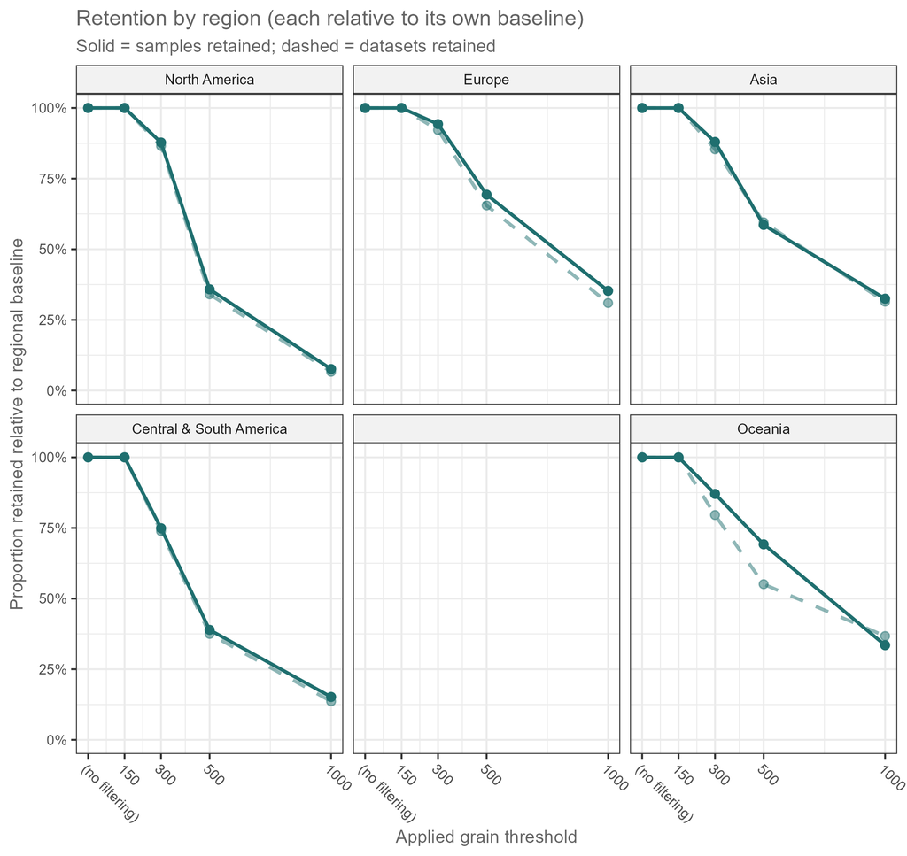

Figure 3: Continent-level retention sensitivity under stricter pollen-sum thresholds.

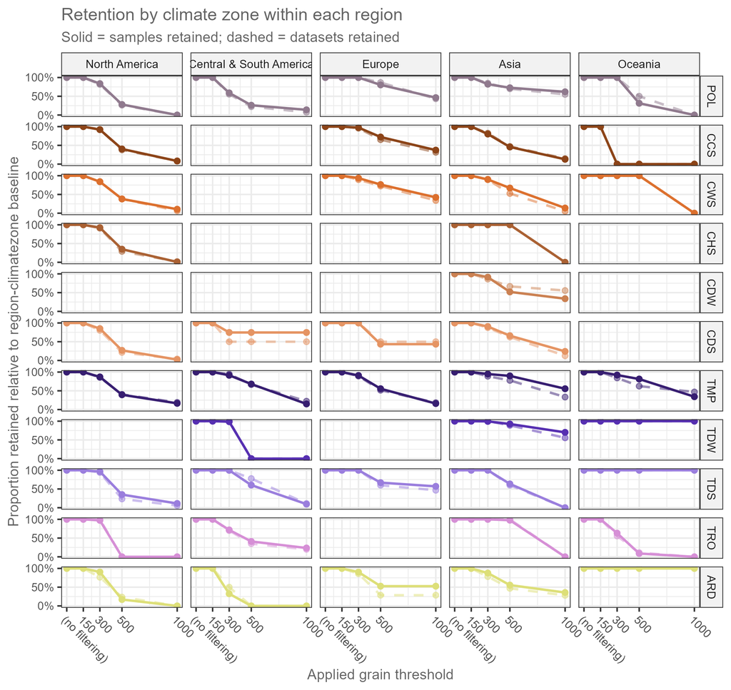

Figure 4: Continent x climate zone retention sensitivity under stricter pollen-sum thresholds.

### Data-derived summary table

Table 1: Overall retention metrics by threshold (derived from pollen_threshold_retention_overall.csv).

| Threshold | Records retained | Samples retained | Record retention | Sample retention |
| --- | --- | --- | --- | --- |
| 150 | 1,270 | 75,383 | 100.0% | 100.0% |
| 300 | 1,105 | 67,846 | 87.0% | 90.0% |
| 500 | 616 | 41,206 | 48.5% | 54.7% |
| 1,000 | 246 | 18,185 | 19.4% | 24.1% |

### Notes for manuscript integration

- Methods: Add a short paragraph distinguishing threshold-based filtering decisions from downstream empirical distribution diagnostics.
- Discussion/limitations: Add a short paragraph framing threshold choice as a bias-coverage trade-off quantified by the sensitivity outputs.